# Supplement 1

## Sex

```r
# Tabular summary
data %>%
    select(sex) %>%
    skim()
```

```
## Skim summary statistics
##  n obs: 83
##  n variables: 1
##
## ── Variable type:factor ────────────────────────────────────────────────────────────────
##  variable missing complete  n n_unique          top_counts ordered
##       sex       0       83 83        2 F: 46, M: 37, NA: 0   FALSE
```

```r
# 95% bootstrap confidence interval of the proportion of females
## Method = BCa, Resamples = 10000
set.seed(1234)
boot.ci(boot(data = data,
             statistic = function(d, i){mean(d[i, 'sex'] == 'F')},
             R = 10000,
             stype = 'i'),
        type = 'bca') %>%
    data_frame(n = nrow(filter(data, !is.na(sex))),
      Proportion = round(.$t0, 3),
      Conf.level = 0.95,
      Bca.lower = round(.$bca[[4]], 3),
      Bca.upper = round(.$bca[[5]], 3)) %>%
    .[1, -1] %>%
    as.data.frame()
```

```
##    n Proportion Conf.level Bca.lower Bca.upper
## 1 83      0.554       0.95     0.434     0.651
```

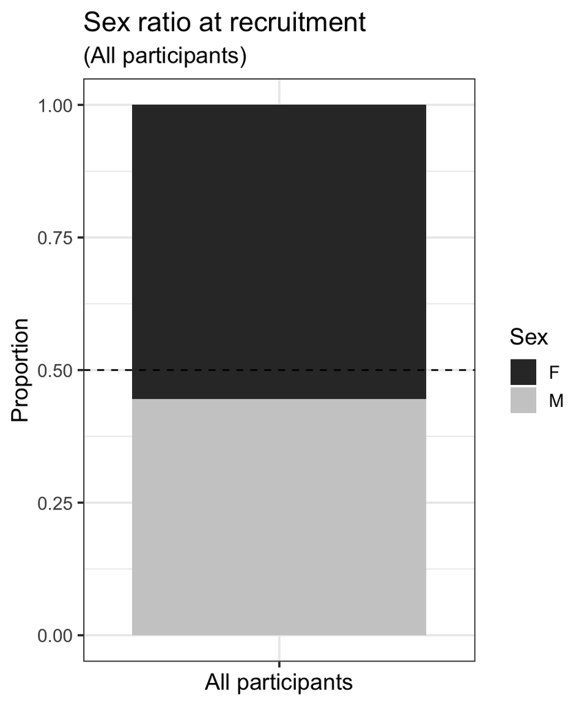

```r
# Plot
data %>%
    ggplot(data = .) +
    aes(x = 'All participants',
        fill = sex) +
    geom_bar(position = 'fill') +
    geom_hline(yintercept = 0.5,
               linetype = 2) +
    labs(title = 'Sex ratio at recruitment',
         subtitle = '(All participants)',
         y = 'Proportion') +
    scale_fill_grey(name = 'Sex') +
    theme(axis.text.x = element_blank())
```

## CD4 T-cell count

```r
# Tabular summary
data %>%
    select(CD4_cell.ul) %>%
    skim()
```

```
## Skim summary statistics
##  n obs: 83
##  n variables: 1
##
## ── Variable type:numeric ───────────────────────────────────────────────────────────────
##     variable missing complete  n   mean    sd p0 p25 p50 p75 p100     hist
##  CD4_cell.ul       0       83 83 243.46 180.9  1 122 234 317  867 ▇▇▇▃▂▁▁▁
```

```r
# 95% bootstrap confidence interval of the median CD4 T-cell count
## Method = BCa, Resamples = 10000
set.seed(1234)
groupwiseMedian(CD4_cell.ul ~ 1,
                data = data,
                R = 10000,
                boot = TRUE,
                bca = TRUE)[c(2:3, 5, 6, 7)]
```

```
##    n Median Conf.level Bca.lower Bca.upper
## 1 83    234       0.95       151       285
```

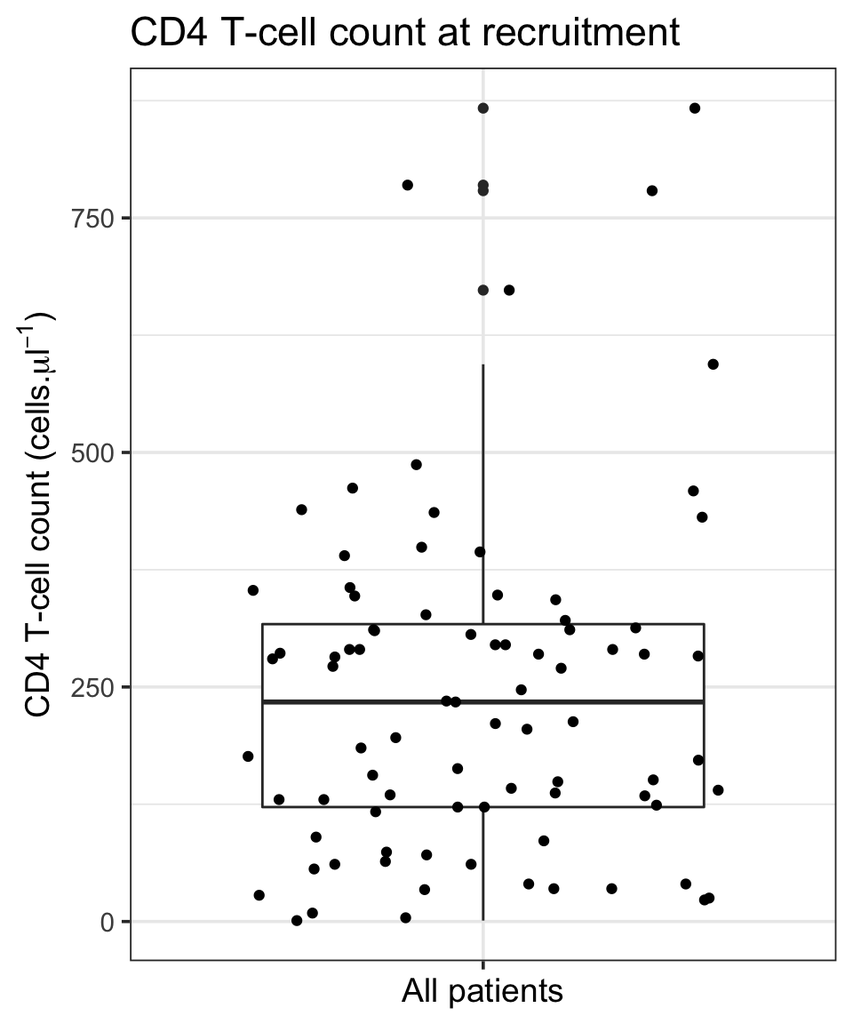

```r
# Plot
data %>%
    ggplot(data = .) +
    aes(y = CD4_cell.ul,
        x = 'All patients') +
    geom_boxplot() +
    geom_jitter(height = 0) +
    labs(title = 'CD4 T-cell count at recruitment',
         y = expression(paste('CD4 T-cell count (cells.', mu, l^-1, ')'))) +
    theme(axis.text.x = element_blank())
```

## Viral load

```r
# Tabular summary
data %>%
    select(viral_load_copies.ml) %>%
    skim()
```

```
## Skim summary statistics
##  n obs: 83
##  n variables: 1
##
## ── Variable type:numeric ───────────────────────────────────────────────────────────────
##              variable missing complete  n mean   sd  p0  p25  p50  p75
##  viral_load_copies.ml       6       77 83 3.42 1.35 1.7 2.21 3.02 4.23
##  p100     hist
##  6.51 ▇▅▆▂▅▂▁▂
```

```r
# 95% bootstrap confidence interval of the median viral load
## Method = BCa, Resamples = 10000
set.seed(1234)
groupwiseMedian(viral_load_copies.ml ~ 1,
                data = data[!is.na(data$viral_load_copies.ml), ], # Remove <NA>
                R = 10000,
                boot = TRUE,
                bca = TRUE)[c(2:3, 5, 6, 7)]
```

```
##    n Median Conf.level Bca.lower Bca.upper
## 1 77   3.02       0.95      2.78      3.38
```

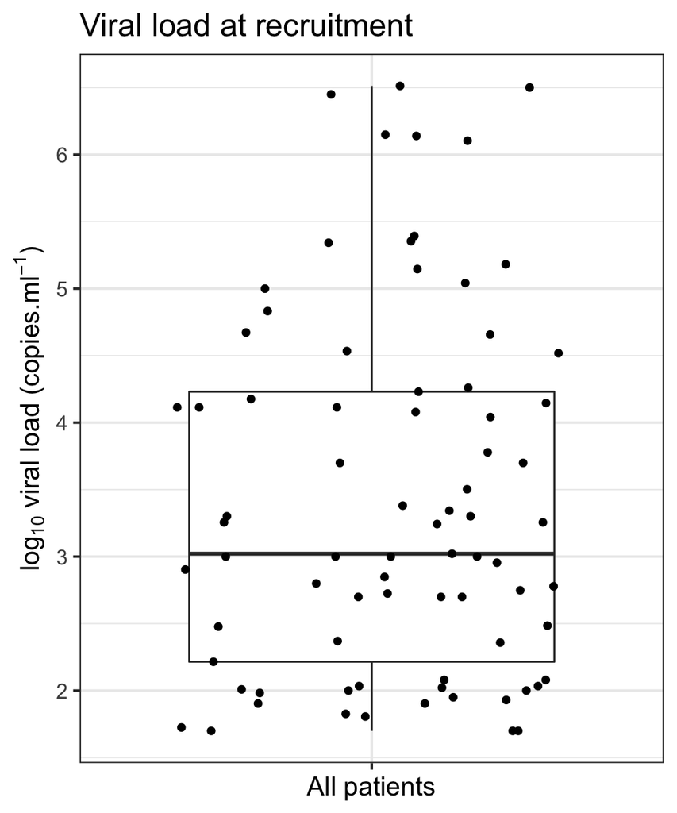

```r
# Plot
data %>%
    filter(!is.na(viral_load_copies.ml)) %>%
    ggplot(data = .) +
    aes(y = viral_load_copies.ml,
        x = 'All patients') +
    geom_boxplot() +
    geom_jitter(height = 0) +
    labs(title = 'Viral load at recruitment',
         y = expression(paste('log' [10], ' viral load (copies.ml' ^-1, ')')))  +
    theme(axis.text.x = element_blank())
```

## Alcohol

```r
# Tabular summary
data %>%
    select(alcohol_units.week) %>%
    mutate(drinks_alcohol = case_when(
        alcohol_units.week >= 1 ~ 'Yes',
        alcohol_units.week == 0 ~ 'No'
    )) %>%
    mutate(drinks_alcohol = factor(drinks_alcohol)) %>%
    group_by(drinks_alcohol) %>%
    skim()
```

```
## Skim summary statistics
##  n obs: 83
##  n variables: 2
##  group variables: drinks_alcohol
##
## ── Variable type:integer ───────────────────────────────────────────────────────────────
##  drinks_alcohol           variable missing complete  n  mean   sd p0 p25
##              No alcohol_units.week       0       67 67  0    0     0   0
##             Yes alcohol_units.week       0       16 16 10.56 7.58  3   4
##  p50 p75 p100     hist
##    0   0    0 ▁▁▁▇▁▁▁▁
##    9  15   29 ▇▃▂▂▁▁▁▁
```

```r
# 95% bootstrap confidence interval of the median alcohol consumption
## Method = BCa, Resamples = 10000
set.seed(1234)
groupwiseMedian(alcohol_units.week ~ 1,
                data = data[data$alcohol_units.week > 0, ], # Remove none drinkers
                R = 10000,
                boot = TRUE,
                bca = TRUE)[c(2:3, 5, 6, 7)]
```

```
##    n Median Conf.level Bca.lower Bca.upper
## 1 16      9       0.95         4        12
```

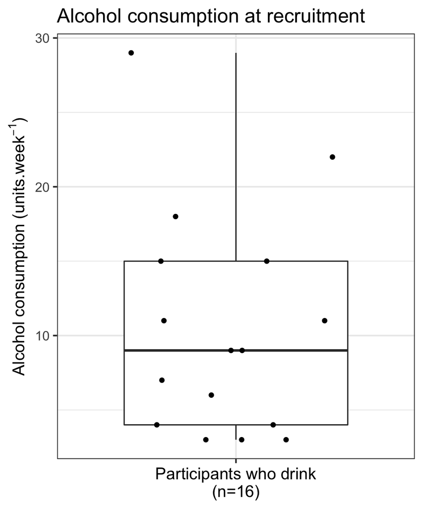

```r
# Plot
data %>%
    filter(alcohol_units.week > 0) %>%
    ggplot(data = .) +
    aes(x = 'Participants who drink\n(n=16)',
        y = alcohol_units.week) +
    geom_boxplot() +
    geom_jitter(height = 0) +
    labs(title = 'Alcohol consumption at recruitment',
         y = expression(paste('Alcohol consumption (units.week' ^-1, ')'))) +
    theme(axis.text.x = element_blank())
```

## TB

*Note: Treatment policy was to start some patients, irrespective of TB diagnosis, on TB treatment. Therefore current TB infection and treatment for TB analysed separately.*

### Currently infected with TB

```r
# Tabular summary
data %>%
    select(TB_current) %>%
    skim()
```

```
## Skim summary statistics
##  n obs: 83
##  n variables: 1
##
## ── Variable type:factor ────────────────────────────────────────────────────────────────
##    variable missing complete  n n_unique             top_counts ordered
##  TB_current       0       83 83        2 no: 67, yes: 16, NA: 0   FALSE
```

```r
# 95% bootstrap confidence interval of the proportion with TB
## Method = BCa, Resamples = 10000
set.seed(1234)
boot.ci(boot(data = data,
             statistic = function(d, i){mean(d[i, 'TB_current'] == 'yes')},
             R = 10000,
             stype = 'i'),
        type = 'bca') %>%
    data_frame(n = nrow(filter(data, !is.na(TB_current))),
      Proportion = round(.$t0, 3),
      Conf.level = 0.95,
      Bca.lower = round(.$bca[[4]], 3),
      Bca.upper = round(.$bca[[5]], 3)) %>%
    .[1, -1] %>%
    as.data.frame()
```

```
##    n Proportion Conf.level Bca.lower Bca.upper
## 1 83      0.193       0.95     0.108     0.277
```

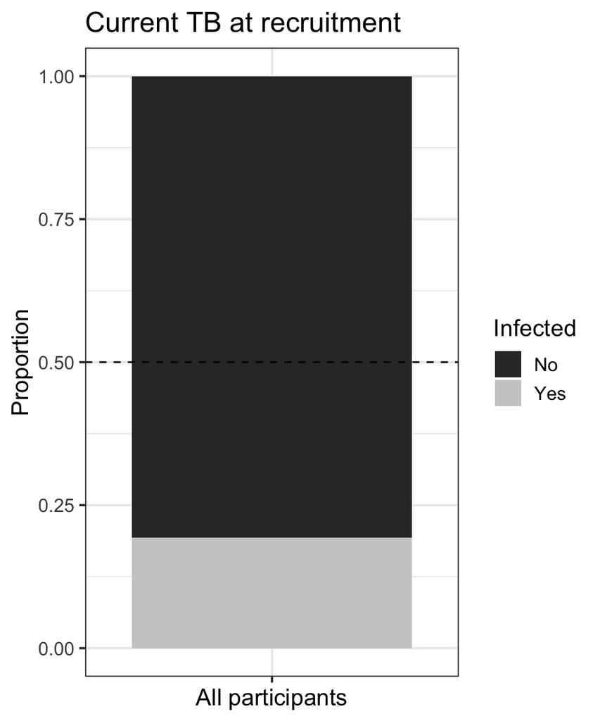

```r
# Plot
data %>%
    mutate(TB_current = str_to_title(TB_current)) %>%
    ggplot(data = .) +
    aes(x = 'All participants',
        fill = TB_current) +
    geom_bar(position = 'fill') +
    geom_hline(yintercept = 0.5,
               linetype = 2) +
    labs(title = 'Current TB at recruitment',
         y = 'Proportion') +
    scale_fill_grey(name = 'Infected') +
    theme(axis.text.x = element_blank())
```

### Currently receiving TB treatment?

Treatment consisted of rifafour and pyridoxine (prophylaxis). Therefore only need to analyse rifafour data. Data coded as *‘No’* (not being treated), *‘Yes’* (being treated for active TB), and *‘Prophylaxis’* (being treated prophylactically for TB).

```r
# Double-check matching between rifafour and pyridoxine columns
unique(data$rifafour_treatment == data$pyridoxine_prophylaxis)
```

```
## [1] TRUE
```

```r
# Tabular summary
data %>%
    group_by(pyridoxine_prophylaxis) %>%
    select(rifafour_treatment, pyridoxine_prophylaxis) %>%
    skim()
```

```
## Skim summary statistics
##  n obs: 83
##  n variables: 2
##  group variables: pyridoxine_prophylaxis
##
## ── Variable type:factor ────────────────────────────────────────────────────────────────
##  pyridoxine_prophylaxis           variable missing complete  n n_unique
##                      no rifafour_treatment       0       66 66        1
##                     yes rifafour_treatment       0       15 15        1
##             prophylaxis rifafour_treatment       0        2  2        1
##                     top_counts ordered
##  no: 66, yes: 0, pro: 0, NA: 0   FALSE
##  yes: 15, no: 0, pro: 0, NA: 0   FALSE
##   pro: 2, no: 0, yes: 0, NA: 0   FALSE
```

```r
# Proportion on prophylaxis treatment
## Too low to analyse separately
round(mean(data$rifafour_treatment == 'prophylaxis'), 3)
```

```
## [1] 0.024
```

```r
## ...so collapse 'yes' and 'prophylaxis'
data_tb <- data %>%
    mutate(rifafour_treatment = fct_collapse(rifafour_treatment,
                                             yes = c('yes', 'prophylaxis')))

# 95% bootstrap confidence interval of the proportion on TB treatment
## Method = BCa, Resamples = 10000
set.seed(1234)
boot.ci(boot(data = data_tb,
             statistic = function(d, i){mean(d[i, 'rifafour_treatment'] == 'yes')},
             R = 10000,
             stype = 'i'),
        type = 'bca') %>%
    data_frame(n = nrow(filter(data_tb, !is.na(rifafour_treatment))),
      Proportion = round(.$t0, 3),
      Conf.level = 0.95,
      Bca.lower = round(.$bca[[4]], 3),
      Bca.upper = round(.$bca[[5]], 3)) %>%
    .[1, -1] %>%
    as.data.frame()
```

```
##    n Proportion Conf.level Bca.lower Bca.upper
## 1 83      0.205       0.95      0.12     0.289
```

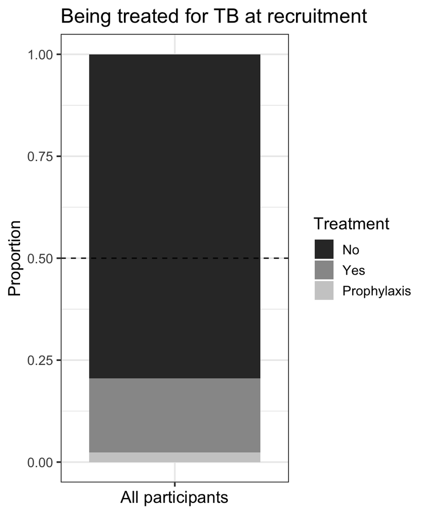

```r
# Plot
data %>%
    mutate(rifafour_treatment = str_to_title(rifafour_treatment),
           rifafour_treatment = factor(rifafour_treatment,
                                       levels = c('No', 'Yes',
                                                  'Prophylaxis'),
                                       ordered = TRUE)) %>%
    ggplot(data = .) +
    aes(x = 'All participants',
        fill = rifafour_treatment) +
    geom_bar(position = 'fill') +
    geom_hline(yintercept = 0.5,
               linetype = 2) +
    labs(title = 'Being treated for TB at recruitment',
         y = 'Proportion') +
    scale_fill_grey(name = 'Treatment') +
    theme(axis.text.x = element_blank())
```

## Diabetes

Classified as diabetic based on `data$hba1c_percent` > 7%. No participants were diabetic.

```r
# Tabular summary
data %>%
    select(diabetic_hba1c) %>%
    skim()
```

```
## Skim summary statistics
##  n obs: 83
##  n variables: 1
##
## ── Variable type:factor ────────────────────────────────────────────────────────────────
##        variable missing complete  n n_unique            top_counts ordered
##  diabetic_hba1c       2       81 83        1 no: 81, NA: 2, yes: 0   FALSE
```

## Vitamin B12 deficiency

Classed as B12 deficient based on `data$vitaminB12_pmol.l` < 141 pmol/l. Only one participant had a deficiency.

```r
# Tabular summary
data %>%
    select(vitaminB12_deficiency) %>%
    skim()
```

```
## Skim summary statistics
##  n obs: 83
##  n variables: 1
##
## ── Variable type:factor ────────────────────────────────────────────────────────────────
##               variable missing complete  n n_unique            top_counts
##  vitaminB12_deficiency       3       80 83        2 no: 79, NA: 3, yes: 1
##  ordered
##    FALSE
```